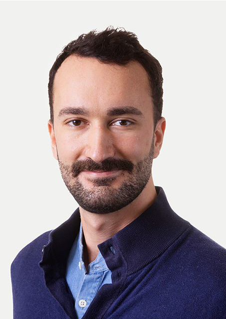

# Loris Jeitziner

#### Research associate @FHNW

**Research Interests**

- Computer-supported collaborative learning (CSCL)
- Methods development in CSCL
- Collaborative engagement in CSCL

**Current Projects**

- [Next-Generation Learning](https://www.fhnw.ch/de/forschung-und-dienstleistungen/psychologie/soziale-und-digitale-interaktion/next-generation-learning)
- [PGB-8 «E-ASSESSMENT & DISTANCE TESTING»](https://newlearning.fhnw.ch/pgb-8-e-assessment-distance-testing/)
- [FHNW Learning Spaces](https://www.fhnw.ch/de/die-fhnw/strategische-entwicklungsschwerpunkte/strategische-initiativen-18-20/learning-spaces)

#### Experience

**Since 2021** Research associate, School of Applied Psychology, University of Applied Sciences and Arts Northwestern Switzerland

**2017 - 2021** Research assistant, Department of Social Psychology, University of Basel

#### Education

**Since 2022** Doctoral candidate, University of Basel

**2019 - 2021** Master of Science Psychology – Social-, Decision- and Economic Psychology, University of Basel, Switzerland

**2016 – 2019** Bachelor of Science Psychology, University of Basel, Switzerland

**2010 – 2014** IT vocational education - System administration, Fr. Sauter AG

#### Selected Publications

- Fischer, O., Jeitziner, L.T. & Wulff, D.U. (2024). Affect in science communication: a data-driven analysis of TED Talks on YouTube. *Humanit Soc Sci Commun* 11, 80. https://doi.org/10.1057/s41599-023-02247-z
- Jaffé, M.E., Jeitziner, L., Keller, M.D., & Walker, M. (2022). Differences in faces do make a difference: Diversity perceptions and preferences in faces. *Journal of Experimental Social Psychology, 100*, 104277. Elsevier. https://doi.org/10.1016/j.jesp.2021.104277
- Paneth, L., Jeitziner, L. T., Rack, O., Opwis, K., & Zahn, C. (2024). Zooming in: The role of nonverbal behavior in sensing the quality of collaborative group engagement. *Intern. J. Comput.-Support. Collab. Learn.* https://doi.org/10.1007/s11412-024-09422-7

#### Conference Proceedings

- Jeitziner, L. T., Paneth, L., Rack, O., Zahn, C., & Wulff, D. U. (2023). Exploring linguistic indicators of social collaborative group engagement. In Damșa, C., Borge, M., Koh, E., & Worsley, M. (Eds.), *Proceedings of the 16th International Conference on Computer-Supported Collaborative Learning* - CSCL 2023 (pp. 364-365). International Society of the Learning Sciences. https://doi.org/10.22318/cscl2023.813595
- Roos, A., Jeitziner, L. T., & Zahn, C. (2023). Stressors in online exams - same same but different?. In Blikstein, P., Van Aalst, J., Kizito, R., & Brennan, K. (Eds.), *Proceedings of the 17th International Conference of the Learning Sciences - ICLS 2023* (pp. 1979-1980). International Society of the Learning Sciences. https://doi.org/10.22318/icls2023.806035
- Paneth, L., Jeitziner, L., Rack, O., Zahn, C. (2023). A Multi-Method Approach to Capture Quality of Collaborative Group Engagement. In C. Damsa, M. Borge, E. Koh, M. Worsley (Eds.), *Proceedings of the 16th International Conference on Computer-Supported Collaborative Learning—CSCL 2023* (pp. 91–98). International Society of the Learning Sciences. https://doi.org/10.22318/cscl2023.134087
- Jeitziner, L.T., Roos, A.-L., Ruf, A., & Zahn, C. (2022). What if the computer crashes? Findings from an exploratory factor analysis on stressors in online exams. In *Proceedings of the 16th International Conference of the Learning Sciences-ICLS 2022* (pp. 1948-1949). International Society of the Learning Sciences. https://dx.doi.org/10.22318/icls2022.1948